# Introduction

```r
library(rstan)
```

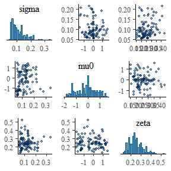

```r
library(bennu)
library(bayesplot)
library(ggplot2)

rstan_options(auto_write = TRUE)
options(mc.cores = 2)

## basic example code
d <- generate_model_data()
# note iter should be at least 2000 to generate a reasonable posterior sample
fit <- est_naloxone(d,iter=100)
mcmc_pairs(fit, pars = c("sigma","mu0","zeta"),
           off_diag_args = list(size = 1, alpha = 0.5))
```

Return median and 90th percentiles for posterior samples

```r
library(posterior)
```

```r
summarise_draws(fit, default_summary_measures())
```

```
#> # A tibble: 462 × 7
#>    variable  mean median    sd   mad    q5    q95
#>    <chr>    <num>  <num> <num> <num> <num>  <num>
#>  1 logp[1]  -1.84  -1.76 0.461 0.427 -2.58 -1.17
#>  2 logp[2]  -1.87  -1.81 0.414 0.397 -2.54 -1.28
#>  3 logp[3]  -1.89  -1.85 0.319 0.312 -2.54 -1.45
#>  4 logp[4]  -1.85  -1.83 0.276 0.251 -2.33 -1.44
#>  5 logp[5]  -1.58  -1.57 0.263 0.252 -1.99 -1.15
#>  6 logp[6]  -1.34  -1.35 0.150 0.159 -1.56 -1.09
#>  7 logp[7]  -1.24  -1.24 0.204 0.208 -1.57 -0.921
#>  8 logp[8]  -1.18  -1.18 0.138 0.132 -1.38 -0.950
#>  9 logp[9]  -1.20  -1.20 0.126 0.145 -1.40 -1.00
#> 10 logp[10] -1.31  -1.33 0.169 0.181 -1.58 -1.06
#> # ℹ 452 more rows
```

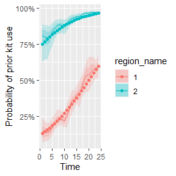

```r
plot_kit_use(model = fit,data=d)
```

We can compare the posterior predictive check to the prior predictive check by re-running the model without the likelihood by setting the `run_estimation` parameter to `FALSE`

```r
# note iter should be at least 2000 to generate a reasonable posterior sample
prior_fit <- est_naloxone(d,
                          run_estimation = FALSE,
                          iter=100)
```

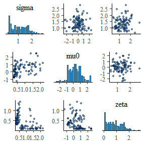

```r
mcmc_pairs(prior_fit, pars = c("sigma","mu0","zeta"),
           off_diag_args = list(size = 1, alpha = 0.5))
```

We can compare the prior and posterior predictive distribution of the probability of prior kit use using the `plot_kit_use` function

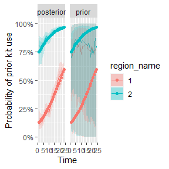

```r
plot_kit_use(prior = prior_fit,posterior = fit, data=d)
```

## Random walk of order 2 model

$$\Delta^2c_i = c_i - c_{i+1} \sim
N(0,\tau^{-1})$$

The model can also be fit using a random walk of order 2 increments for the inverse logit probability of naloxone use using the following independent second order increments,

$$\Delta^2c_i = c_i - 2c_{i+1} + c_{i+2}
\sim N(0,\tau^{-1})$$

This version of the model will produce smoother estimates of probability of naloxone use in time.

```r
# note iter should be at least 2000 to generate a reasonable posterior sample
# note use `rw_type` to specify order of random walk
rw2_fit <- est_naloxone(d,
                    rw_type = 2,
                    iter=100)
```

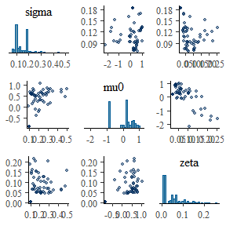

```r
mcmc_pairs(rw2_fit, pars = c("sigma","mu0","zeta"),
           off_diag_args = list(size = 1, alpha = 0.5))
```

Summarize random walk order 2 model draws

```r
summarise_draws(rw2_fit, default_convergence_measures())
```

```
#> # A tibble: 462 × 4
#>    variable  rhat ess_bulk ess_tail
#>    <chr>    <num>    <num>    <num>
#>  1 logp[1]   2.29     12.5     20.1
#>  2 logp[2]   1.90     13.1     26.5
#>  3 logp[3]   1.88     10.5     24.2
#>  4 logp[4]   1.78     21.0    107.
#>  5 logp[5]   1.29     13.9     76.6
#>  6 logp[6]   1.21     17.4    102.
#>  7 logp[7]   1.33     16.1     89.6
#>  8 logp[8]   1.64     37.0     52.0
#>  9 logp[9]   1.93     27.7    142.
#> 10 logp[10]  2.01     14.5     50.8
#> # ℹ 452 more rows
```

We can compare two different model fits of the probability of prior kit use to simulated data using the `plot_kit_use` function

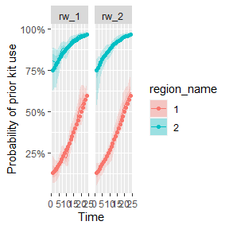

```r
plot_kit_use(rw_1 = fit,rw_2 = rw2_fit,data=d)
```

## fit missing distribution data

As distribution data are reported from sites some months may not be reported. This would lead to a difference in the frequency of the orders data and the distribution data. The model can account for these differences and infer the distribution during missing months. See the following example for generating distribution data once every three months

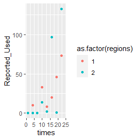

```r
## basic example code
d_missing <- generate_model_data(reporting_freq = 3)
ggplot(aes(x=times,y=Reported_Used,color=as.factor(regions)),data=d_missing) +
  geom_point()
```

```r
missing_fit <- est_naloxone(d_missing,
                    rw_type = 2,
                    iter=100)
```

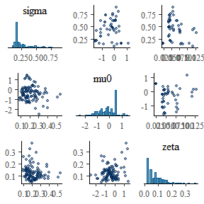

```r
mcmc_pairs(missing_fit, pars = c("sigma","mu0","zeta"),
           off_diag_args = list(size = 1, alpha = 0.5))
```

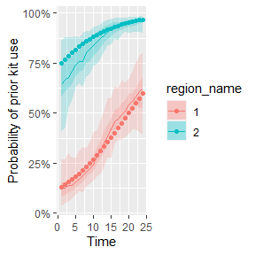

```r
plot_kit_use(model = missing_fit, data=d_missing)
```

## Change scale of data

the original model was designed for data aggregated into months. If the order and distribution data is aggregated differently then this can be incorporated into the model by updating the delay in reporting distribution and the delay in ordering to distributing distribution.

The delay in ordering to distributing distribution is composed of a gamma distribution with shape parameter $\alpha$ and inverse scale parameter $\beta = 1/\theta$. In order to update for example from monthly to weekly data, we can use the following property of the gamma distribution,

$$\Gamma(cx;\alpha,\beta) =
\Gamma(x;\alpha,\beta/c)$$

```r
# monthly reporting delay distribution
psi_vec <- c(0.7, 0.2, 0.1)
# convert to weeks using interpolation
weekly_psi_vec <- rep(psi_vec,4) / sum(psi_vec)

# properties of order to distributed delay distribution in months
max_delays <- 3
delay_alpha <- 2
delay_beta <- 1

# convert to weeks
weekly_max_delays <- max_delays*4
weekly_delay_alpha <- delay_alpha
weekly_delay_beta <- 0.25 * delay_beta

result <- est_naloxone(d,
 psi_vec = weekly_psi_vec,
 max_delays = weekly_max_delays,
 delay_alpha = weekly_delay_alpha,
 delay_beta = weekly_delay_beta)
```